# LLM-Identity Decomposition: Per-Model Asymmetry within HA and AA

Does dyad asymmetry depend on which LLM is in the conversation?

PENPAL Project

2026-05-04

# Overview

The cross-condition notebooks treat HA and AA as monoliths. This notebook decomposes both by which LLM is in the dyad and asks two questions per metric:

1. **Per-LLM magnitude.** Does unsigned asymmetry $A_m$ vary across the four LLMs within HA? Within AA?
2. **Per-LLM direction.** Does signed slot-asymmetry vary across LLMs (i.e. are some models more likely to drive in a particular direction)?

Where it makes sense, the same-model rows in HA and AA are placed side-by-side: does Claude paired with a human exhibit the same asymmetry profile as Claude paired with itself?

# Build per-metric per-story tables

```
## Per-story tables built:
##   valence: 140 (HA=100, AA=40)
##   novelty: 140 (HA=100, AA=40)
##   semexp:  137 (HA=97, AA=40)
```

# Within-HA: per-LLM Asymmetry

## Magnitude

Per-LLM unsigned asymmetry magnitude within HA

| metric | llm | n | mean | median | sd |
| --- | --- | --- | --- | --- | --- |
| A_valence | GPT-4.1 | 23 | 0.712 | 0.618 | 0.633 |
| A_valence | Claude-sonnet-4-5 | 22 | 0.574 | 0.364 | 0.477 |
| A_valence | Llama-3.3-70B | 29 | 0.682 | 0.566 | 0.468 |
| A_valence | Qwen2.5-72B | 26 | 0.604 | 0.451 | 0.440 |
| A_influence | GPT-4.1 | 23 | 0.442 | 0.453 | 0.275 |
| A_influence | Claude-sonnet-4-5 | 22 | 0.455 | 0.436 | 0.348 |
| A_influence | Llama-3.3-70B | 29 | 0.379 | 0.294 | 0.346 |
| A_influence | Qwen2.5-72B | 26 | 0.447 | 0.434 | 0.312 |
| A_semexp | GPT-4.1 | 23 | 0.200 | 0.195 | 0.158 |
| A_semexp | Claude-sonnet-4-5 | 21 | 0.137 | 0.091 | 0.110 |
| A_semexp | Llama-3.3-70B | 27 | 0.192 | 0.192 | 0.098 |
| A_semexp | Qwen2.5-72B | 26 | 0.264 | 0.220 | 0.192 |

Within-HA Kruskal-Wallis: A_m ~ llm

| metric | kw_p |
| --- | --- |
| A_valence | 0.7988 |
| A_influence | 0.6515 |
| A_semexp | 0.0521 |

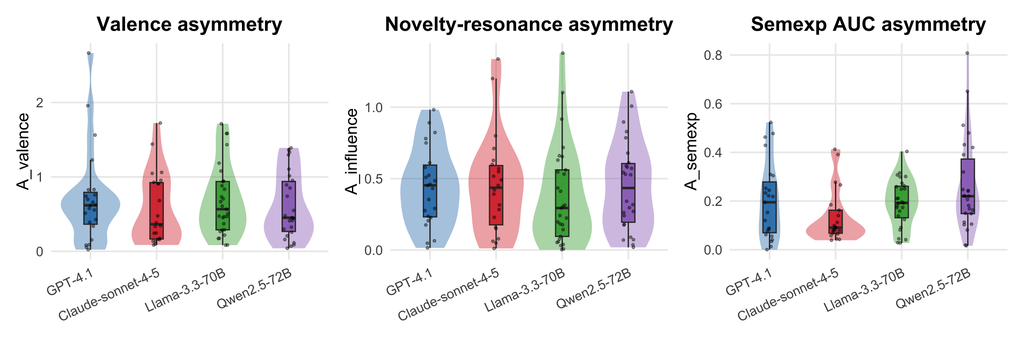

## Direction

Per-LLM directional stability of the SIGNED slot difference within HA. If the human-side identity is what drives directionality, all four LLMs should look similar (same signed direction). If specific LLMs shape directionality (e.g., Claude is more deferential than Qwen), the stability index will differ across models.

Within-HA directional stability of signed asymmetry per LLM

| metric | llm | n | mean | sd | stability | sign_consistency | one_sample_t_p |
| --- | --- | --- | --- | --- | --- | --- | --- |
| valence | GPT-4.1 | 23 | 0.250 | 0.930 | 0.268 | 0.522 | 0.211 |
| valence | Claude-sonnet-4-5 | 22 | 0.181 | 0.733 | 0.247 | 0.682 | 0.259 |
| valence | Llama-3.3-70B | 29 | 0.293 | 0.782 | 0.374 | 0.690 | 0.054 |
| valence | Qwen2.5-72B | 26 | 0.080 | 0.752 | 0.107 | 0.500 | 0.592 |
| novelty | GPT-4.1 | 23 | -0.089 | 0.521 | 0.170 | 0.565 | 0.422 |
| novelty | Claude-sonnet-4-5 | 22 | 0.024 | 0.581 | 0.042 | 0.545 | 0.845 |
| novelty | Llama-3.3-70B | 29 | -0.015 | 0.518 | 0.030 | 0.552 | 0.874 |
| novelty | Qwen2.5-72B | 26 | 0.117 | 0.540 | 0.217 | 0.615 | 0.278 |
| semexp | GPT-4.1 | 23 | -0.012 | 0.258 | 0.045 | 0.565 | 0.832 |
| semexp | Claude-sonnet-4-5 | 21 | 0.061 | 0.167 | 0.363 | 0.571 | 0.112 |
| semexp | Llama-3.3-70B | 27 | -0.035 | 0.216 | 0.161 | 0.593 | 0.410 |
| semexp | Qwen2.5-72B | 26 | -0.126 | 0.304 | 0.416 | 0.654 | 0.044 |

Variance-equality across LLMs (within HA)

| metric | brown_forsythe_p |
| --- | --- |
| valence | 0.6929 |
| novelty | 0.8671 |
| semexp | 0.0431 |

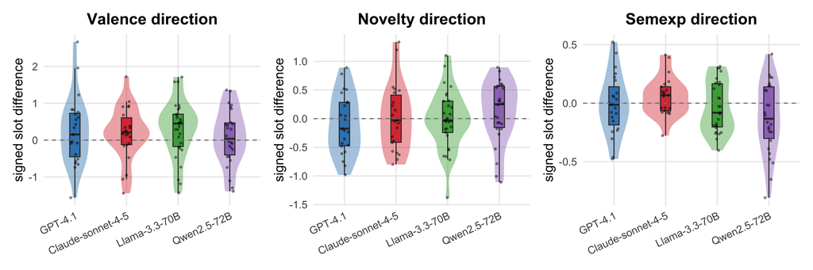

# Within-AA: per-Model Asymmetry

The AA dataset only contains same-model self-pairings (no cross-model pairs). The four levels are therefore pure within-model ai-vs-ai conversations.

## Magnitude

Per-model unsigned asymmetry magnitude within AA

| metric | llm | n | mean | median | sd |
| --- | --- | --- | --- | --- | --- |
| A_valence | GPT-4.1 | 10 | 0.612 | 0.530 | 0.440 |
| A_valence | Claude-sonnet-4-5 | 10 | 0.666 | 0.457 | 0.490 |
| A_valence | Llama-3.3-70B | 10 | 0.393 | 0.302 | 0.338 |
| A_valence | Qwen2.5-72B | 10 | 0.455 | 0.325 | 0.423 |
| A_influence | GPT-4.1 | 10 | 0.360 | 0.297 | 0.206 |
| A_influence | Claude-sonnet-4-5 | 10 | 0.454 | 0.365 | 0.408 |
| A_influence | Llama-3.3-70B | 10 | 0.459 | 0.358 | 0.317 |
| A_influence | Qwen2.5-72B | 10 | 0.325 | 0.324 | 0.238 |
| A_semexp | GPT-4.1 | 10 | 0.141 | 0.076 | 0.145 |
| A_semexp | Claude-sonnet-4-5 | 10 | 0.157 | 0.118 | 0.122 |
| A_semexp | Llama-3.3-70B | 10 | 0.255 | 0.253 | 0.185 |
| A_semexp | Qwen2.5-72B | 10 | 0.119 | 0.127 | 0.082 |

Within-AA Kruskal-Wallis: A_m ~ model

| metric | kw_p |
| --- | --- |
| A_valence | 0.2257 |
| A_influence | 0.8430 |
| A_semexp | 0.2783 |

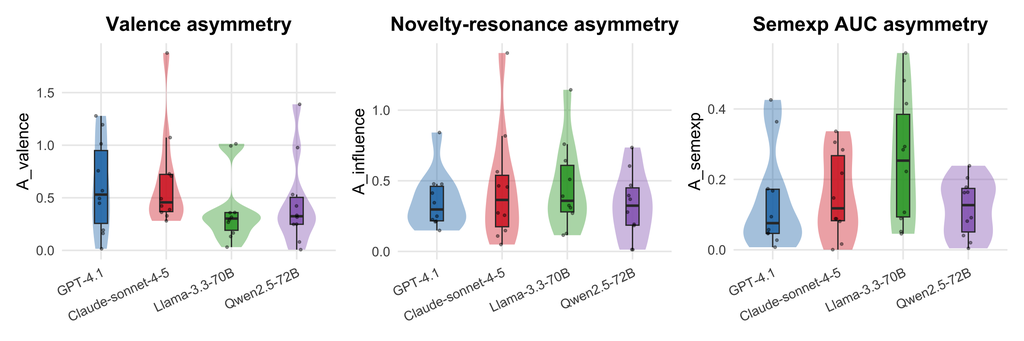

## Direction

Within-AA directional stability of signed asymmetry per model

| metric | llm | n | mean | sd | stability | sign_consistency | one_sample_t_p |
| --- | --- | --- | --- | --- | --- | --- | --- |
| valence | GPT-4.1 | 10 | 0.484 | 0.591 | 0.819 | 0.8 | 0.029 |
| valence | Claude-sonnet-4-5 | 10 | -0.224 | 0.822 | 0.273 | 0.6 | 0.411 |
| valence | Llama-3.3-70B | 10 | -0.065 | 0.530 | 0.122 | 0.7 | 0.708 |
| valence | Qwen2.5-72B | 10 | 0.150 | 0.620 | 0.242 | 0.5 | 0.463 |
| novelty | GPT-4.1 | 10 | -0.047 | 0.429 | 0.109 | 0.5 | 0.737 |
| novelty | Claude-sonnet-4-5 | 10 | -0.204 | 0.591 | 0.346 | 0.6 | 0.302 |
| novelty | Llama-3.3-70B | 10 | 0.103 | 0.568 | 0.182 | 0.5 | 0.579 |
| novelty | Qwen2.5-72B | 10 | 0.040 | 0.415 | 0.097 | 0.6 | 0.766 |
| semexp | GPT-4.1 | 10 | -0.025 | 0.206 | 0.122 | 0.5 | 0.708 |
| semexp | Claude-sonnet-4-5 | 10 | -0.082 | 0.186 | 0.441 | 0.8 | 0.196 |
| semexp | Llama-3.3-70B | 10 | 0.063 | 0.319 | 0.196 | 0.6 | 0.550 |
| semexp | Qwen2.5-72B | 10 | 0.015 | 0.149 | 0.100 | 0.5 | 0.759 |

Variance-equality across models (within AA)

| metric | brown_forsythe_p |
| --- | --- |
| valence | 0.6494 |
| novelty | 0.7260 |
| semexp | 0.1801 |

# Same Model Across Conditions: HA vs AA per-LLM

For each LLM, place its HA stories (paired with a human) next to its AA stories (paired with itself). Asks whether a given model’s asymmetry profile depends on partner type.

[figure not shown]

HA vs AA per-LLM Wilcoxon (BH-adjusted within metric)

| metric | llm | n_HA | n_AA | median_HA | median_AA | cliff_delta | wilcox_p | p_BH |
| --- | --- | --- | --- | --- | --- | --- | --- | --- |
| valence | GPT-4.1 | 23 | 10 | 0.618 | 0.530 | 0.043 | 0.862 | 0.862 |
| valence | Claude-sonnet-4-5 | 22 | 10 | 0.364 | 0.457 | -0.236 | 0.305 | 0.450 |
| valence | Llama-3.3-70B | 29 | 10 | 0.566 | 0.302 | 0.393 | 0.069 | 0.275 |
| valence | Qwen2.5-72B | 26 | 10 | 0.451 | 0.325 | 0.215 | 0.337 | 0.450 |
| novelty | GPT-4.1 | 23 | 10 | 0.453 | 0.297 | 0.209 | 0.363 | 0.484 |
| novelty | Claude-sonnet-4-5 | 22 | 10 | 0.436 | 0.365 | 0.045 | 0.857 | 0.857 |
| novelty | Llama-3.3-70B | 29 | 10 | 0.294 | 0.358 | -0.214 | 0.332 | 0.484 |
| novelty | Qwen2.5-72B | 26 | 10 | 0.434 | 0.324 | 0.208 | 0.355 | 0.484 |
| semexp | GPT-4.1 | 23 | 10 | 0.195 | 0.076 | 0.261 | 0.253 | 0.505 |
| semexp | Claude-sonnet-4-5 | 21 | 10 | 0.091 | 0.118 | -0.114 | 0.633 | 0.633 |
| semexp | Llama-3.3-70B | 27 | 10 | 0.192 | 0.253 | -0.193 | 0.389 | 0.519 |
| semexp | Qwen2.5-72B | 26 | 10 | 0.220 | 0.127 | 0.515 | 0.017 | 0.068 |

# Discussion-friendly summary tables

Quick-read summary across all metrics: which LLMs (if any) stand out on magnitude, on direction, and on partner-sensitivity?

Directional stability per LLM, by condition (Human-AI vs AI-AI)

| condition | metric | llm | n | stability | sign_consistency | one_sample_t_p |
| --- | --- | --- | --- | --- | --- | --- |
| AI-AI | novelty | GPT-4.1 | 10 | 0.109 | 0.500 | 0.737 |
| AI-AI | novelty | Claude-sonnet-4-5 | 10 | 0.346 | 0.600 | 0.302 |
| AI-AI | novelty | Llama-3.3-70B | 10 | 0.182 | 0.500 | 0.579 |
| AI-AI | novelty | Qwen2.5-72B | 10 | 0.097 | 0.600 | 0.766 |
| AI-AI | semexp | GPT-4.1 | 10 | 0.122 | 0.500 | 0.708 |
| AI-AI | semexp | Claude-sonnet-4-5 | 10 | 0.441 | 0.800 | 0.196 |
| AI-AI | semexp | Llama-3.3-70B | 10 | 0.196 | 0.600 | 0.550 |
| AI-AI | semexp | Qwen2.5-72B | 10 | 0.100 | 0.500 | 0.759 |
| AI-AI | valence | GPT-4.1 | 10 | 0.819 | 0.800 | 0.029 |
| AI-AI | valence | Claude-sonnet-4-5 | 10 | 0.273 | 0.600 | 0.411 |
| AI-AI | valence | Llama-3.3-70B | 10 | 0.122 | 0.700 | 0.708 |
| AI-AI | valence | Qwen2.5-72B | 10 | 0.242 | 0.500 | 0.463 |
| Human-AI | novelty | GPT-4.1 | 23 | 0.170 | 0.565 | 0.422 |
| Human-AI | novelty | Claude-sonnet-4-5 | 22 | 0.042 | 0.545 | 0.845 |
| Human-AI | novelty | Llama-3.3-70B | 29 | 0.030 | 0.552 | 0.874 |
| Human-AI | novelty | Qwen2.5-72B | 26 | 0.217 | 0.615 | 0.278 |
| Human-AI | semexp | GPT-4.1 | 23 | 0.045 | 0.565 | 0.832 |
| Human-AI | semexp | Claude-sonnet-4-5 | 21 | 0.363 | 0.571 | 0.112 |
| Human-AI | semexp | Llama-3.3-70B | 27 | 0.161 | 0.593 | 0.410 |
| Human-AI | semexp | Qwen2.5-72B | 26 | 0.416 | 0.654 | 0.044 |
| Human-AI | valence | GPT-4.1 | 23 | 0.268 | 0.522 | 0.211 |
| Human-AI | valence | Claude-sonnet-4-5 | 22 | 0.247 | 0.682 | 0.259 |
| Human-AI | valence | Llama-3.3-70B | 29 | 0.374 | 0.690 | 0.054 |
| Human-AI | valence | Qwen2.5-72B | 26 | 0.107 | 0.500 | 0.592 |

# Summary

Article-use notes: - Use the Within-HA per-LLM table to support a sentence in the Discussion on whether the HA finding is model-general or model-driven. - Use Within-AA per-LLM to qualify the structural-null result: if AA’s rubber-band excess is concentrated in one model (likely Claude or GPT), this reads as model-specific homogenization, not “AI-AI dyads in general”. - Use HA vs AA per-LLM as a partner-sensitivity panel that complements the three primary cross-condition tests.

*Analysis completed: 2026-05-04 18:04:11.013917*